# Descriptive Analytics of the MRIO Demand Structure

Anticipating Circular Economy Simulation Outcomes from Input-Output Accounting Identities

Author

Affiliation

Oriol Vallès Codina

Johns Hopkins University, Net Zero Industrial Policy Lab, Department of Political Science

Published

March 24, 2026

# 1 Overview

This section documents the **multi-regional input-output (MRIO) structure of demand** for eight key material pairs in the EU and Rest of World (RoW), as calibrated in the SOCIO-ECO-MRIO-SFC model at its baseline steady state (period $t = 70$). The figures presented here are **descriptive statistics** derived analytically from the IO accounting framework — they do not require running full simulations.

Their purpose is twofold. First, they provide a transparent characterisation of the demand architecture that sustains primary material production across regions and institutional channels. Second, and more importantly for this paper, they serve as **anticipatory analytics**: each figure is a direct empirical measurement of one of the formal variables derived in the Formal Setup section — the demand channel volumes $D_i^c, D_i^g, D_i^{id}, D_i^{ig}, \sum_j a_{1j}x_j$ that constitute the scale factor in $\Delta M_1 = \rho\,[D_i^c + D_i^g + D_i^{id} + D_i^{ig} + \sum_j a_{1j}x_j]\cdot(l_{12}-l_{11})$. Because $(l_{12}-l_{11})\approx -1$ is constant across all eight material pairs, the ranking of CE interventions by ecological impact reduces entirely to a ranking of these channel volumes, which the figures below measure directly.

# 2 Demand Structure of Material Sectors

## 2.1 Gross Output by Demand Channel

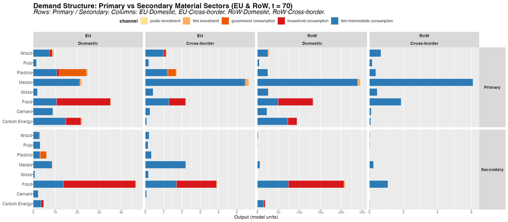

Figure 1: Gross output decomposition for primary and secondary material sectors across EU and RoW. Columns: EU Domestic, EU Cross-border, RoW Domestic, RoW Cross-border demand. Rows: Primary vs Secondary. Bars stacked by institutional demand channel.

Figure 1 decomposes gross output for all eight material pairs by institutional demand channel (household consumption, government consumption, firm investment, public investment, and firm intermediate consumption) across four regional flow dimensions: EU domestic production for EU demand, EU cross-border imports from RoW, RoW domestic production, and RoW cross-border exports to EU.

**Key patterns:**

## 2.2 Demand Composition (% of Primary + Secondary Combined)

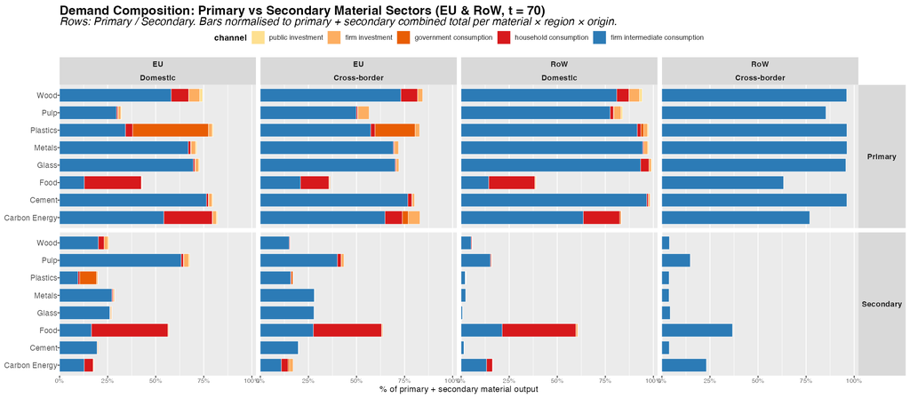

Figure 2: Demand channel composition for primary and secondary material sectors, normalised to 100% of combined (primary + secondary) gross output per material × region × origin column. Enables direct comparison of channel mix between primary and secondary sectors.

Figure 2 normalises each bar to the combined primary plus secondary gross output, making the compositional differences between primary and secondary sectors directly visible.

**Key highlights:**

- For **Carbon Energy** (Fossil-Fuel → Renewable Electricity), secondary output (renewables) is substantially more intermediate-heavy than primary (fossil fuels), reflecting that renewable electricity is primarily procured by industrial users through long-term contracts and grid operators, while fossil-fuel electricity has a larger direct household retail component.
- For **Food** (Meat → Other Food), the primary and secondary channel compositions are similar, suggesting that secondary food markets replicate the institutional structure of conventional meat markets — a positive sign for the scalability of substitution interventions.
- The **EU domestic vs cross-border** column comparison reveals that cross-border (import) demand tends to be more intermediate-heavy, particularly for manufactured materials (plastics, metals). This reflects the role of global value chains in sourcing industrial inputs from RoW suppliers.

# 3 Import Structure: EU Demand for RoW Goods

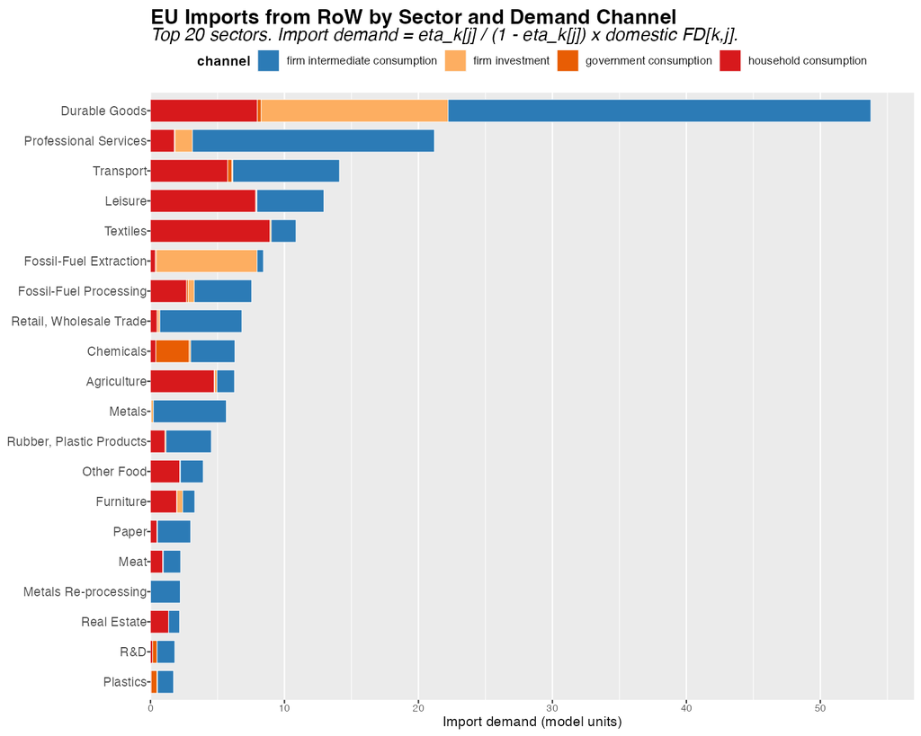

Figure 3: EU import demand from RoW decomposed by sector and demand channel. Includes firm intermediate consumption, household consumption, government consumption, and firm investment. Top 20 sectors by total import demand.

Figure 3 maps the cross-border component of EU demand — imports from RoW — broken down by institutional channel, including both final demand channels (households, government, firm investment) and firm intermediate consumption. Import propensities are calibrated directly from the MARIO MRIO source table (F21/F11 block), rather than using the $\kappa$/$\lambda$ approximation from prior model versions.

**Key highlights:**

# 4 CE Policy Portfolio Effectiveness

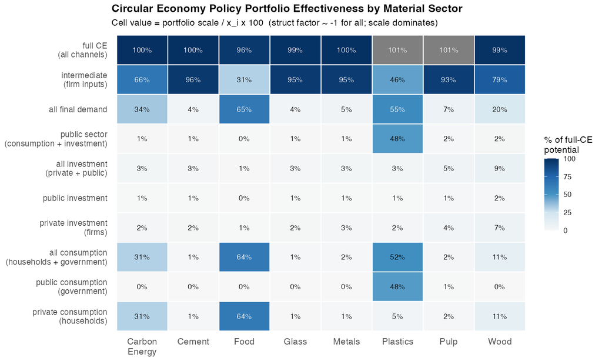

Figure 4: CE policy portfolio effectiveness by material sector. Cell values report the portfolio scale as a percentage of gross output x_i, which — given the structural factor (l_i2 - l_i1) approximately -1 for all materials — equals the percentage of full-CE potential captured by that portfolio at substitution intensity rho = 0.2.

This figure is the key analytical bridge between the IO structure and the simulation outcomes. Because the structural factor is approximately constant across all material pairs, **differences in simulation outcomes will be driven almost entirely by differences in portfolio scale**, not by variation in the IO multiplier. The heatmap therefore anticipates the ordering of cumulative material savings, emission reductions, and macroeconomic effects across scenarios.

**Key findings:**

- **Intermediate production substitution dominates for all industrial materials.** For cement, metals, glass, and pulp, the intermediate channel alone captures 93–96% of the full-CE benchmark. Any final demand portfolio — even combining all four institutional components — recovers less than 8% of potential. This is not a marginal advantage of production-side policy; it is a **categorical difference in order of magnitude**.
- **Plastics: government procurement equals intermediate substitution.** For plastics, the government consumption channel alone (47.5%) is comparable to the intermediate channel (45.9%) and far exceeds household consumption (4.6%). This formal equivalence — unique among the eight materials — reflects the institutional dominance of government procurement in the EU plastics market and makes circular public procurement a first-order policy instrument alongside production-side regulation.
- **Food (Meat → Other Food): the household channel leads.** At 63.8%, household consumption is the dominant CE lever for food — the only material where this is true. Even so, the intermediate channel adds a complementary 31%, pointing to the importance of food processing and catering supply chains.
- **Carbon Energy (Fossil-Fuel → Renewable Electricity): intermediate dominates over household behaviour.** Despite public discourse focusing on household energy transitions, household consumption captures only 30.6% of the full-CE potential for carbon energy. The intermediate channel captures 66.1%. Industrial energy procurement — not consumer behaviour — is the primary driver of fossil-fuel electricity demand.

# 5 Intermediate Demand Decomposition: Key Using Sectors

## 5.1 Absolute Intermediate Demand

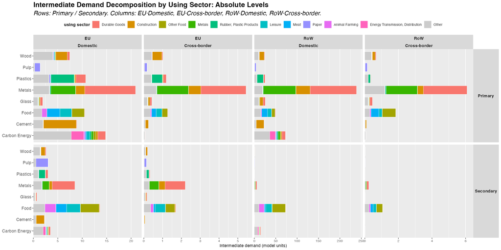

Figure 5: Intermediate demand decomposed by using sector (top 10 globally ranked by total contribution). Primary (top) and Secondary (bottom) sectors shown separately. Columns: EU Domestic, EU Cross-border, RoW Domestic, RoW Cross-border.

## 5.2 Composition (% of Total Intermediate Demand)

[figure not shown]

Figure 6: Intermediate demand composition as percentage of total intermediate demand per material × region × origin. Same layout as Figure 5.

Figures 5 and 6 decompose the intermediate demand channel for each material into the specific producing sectors whose procurement decisions drive it, across EU and RoW and for both domestic and cross-border demand flows.

**Key highlights:**

- **Construction is a cross-material nexus.** Construction appears as a dominant intermediate user of cement, metals, wood, and glass simultaneously. This cross-material character implies that circular construction standards — mandating recycled aggregates, secondary steel, engineered timber, and cullet glass — would cascade through multiple primary sectors concurrently. In the simulations, scenarios targeting construction-linked materials will exhibit correlated output and employment effects across sectors.
- **The energy sector is self-referential for Carbon Energy (Fossil-Fuel Electricity).** Energy transmission and distribution is the largest intermediate user of fossil-fuel electricity, reflecting the upstream-downstream structure of electricity value chains. Renewable energy mandates applied at the generation stage therefore engage the dominant intermediate user directly.
- **Rubber and plastics products dominate plastics intermediate demand.** The plastics processing industry is the principal user of primary plastic resins, creating a concentrated channel for mandatory recycled content requirements.
- **EU vs RoW divergences** in the identity and magnitude of key using sectors imply that CE policies calibrated to EU supply chain structures may not engage the dominant using sectors in RoW. Cross-border spillovers of EU CE policy will be material-specific, with construction-linked materials exhibiting stronger cross-regional transmission.

# 6 Full Supply-Chain Upstream Requirements (Leontief)

## 6.1 Primary Sectors

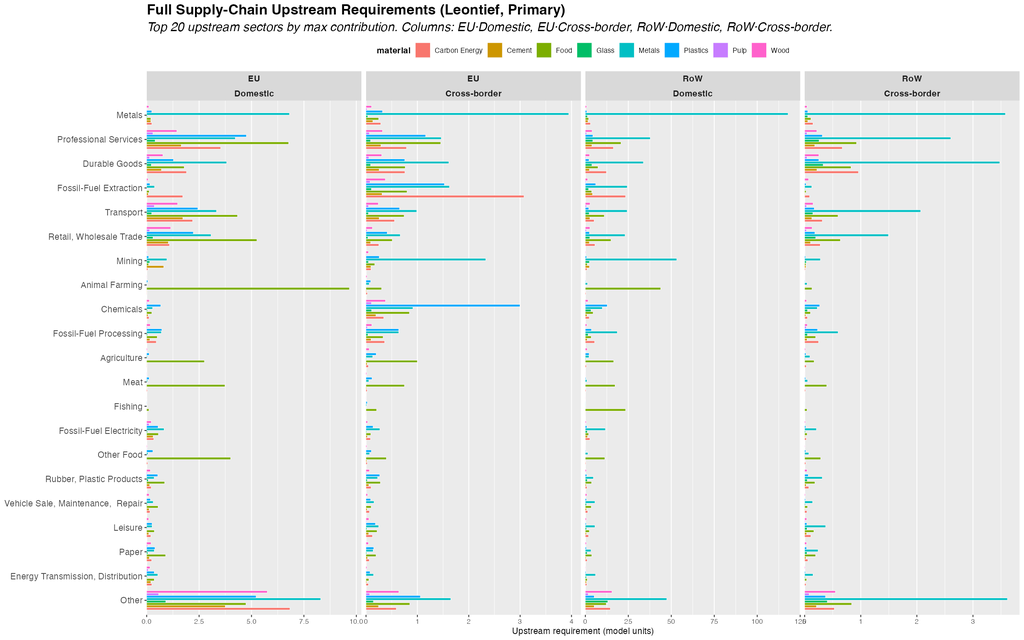

## 6.2 Secondary Sectors

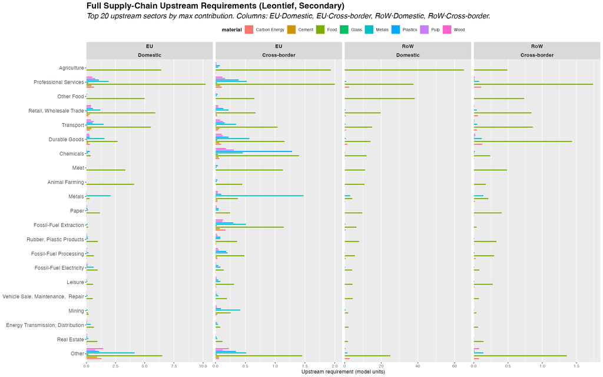

Figure 8: Full supply-chain upstream input requirements for secondary (circular) material sectors. Same layout as Figure 7. Differences relative to Figure 7 identify where primary and secondary supply chains diverge in their upstream structure.

Figures 7 and 8 present the **column view of the Leontief upstream decomposition**: $(L - I)_{ki} \cdot x_i$, showing which sectors $k$ are required as inputs — across all orders of IO interdependence — to sustain the gross output $x_i$ of each material sector $i$. This is the full supply-chain view, encompassing not just direct inputs (captured by the $A$ matrix) but all indirect upstream requirements propagated through the IO system.

The column view is qualitatively different from the intermediate demand decomposition (Figures 5–6). Intermediate demand shows who directly purchases from material sector $i$; the Leontief upstream view shows what sector $i$ itself requires, tracing backwards through all production stages.

**Key highlights:**

# 7 Environmental Impact Estimates

## 7.1 CO2 Emissions

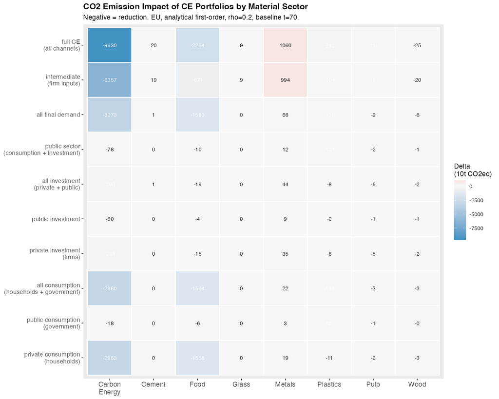

Figure 9: Analytical first-order CO2 emission impact (Delta, 10t CO2eq) of CE portfolios by material sector. Negative = reduction. Based on sector-level emission intensities at t=70 and the Leontief output change formula. EU region, rho = 0.2.

## 7.2 Material Intensity

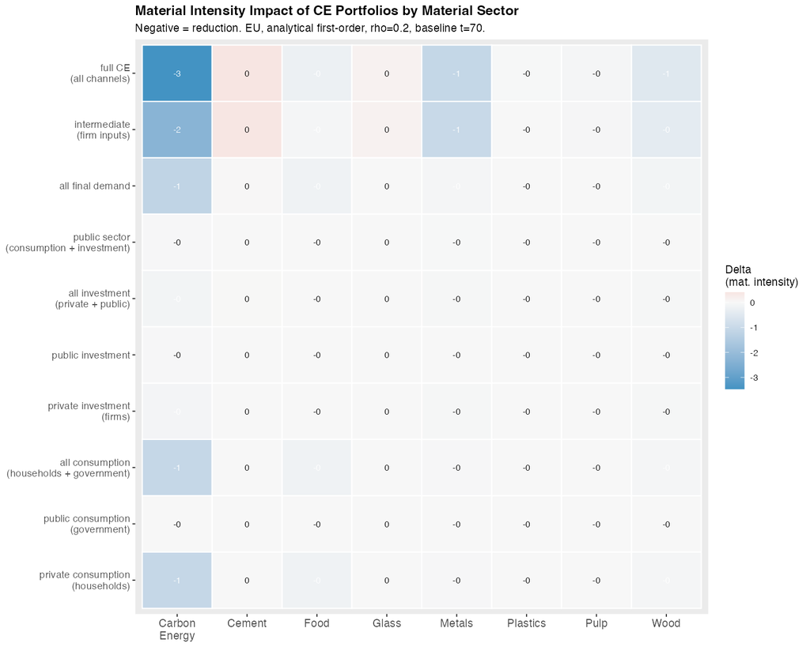

Figure 10: Analytical first-order material intensity impact (Delta) of CE portfolios by material sector. Negative = reduction. mu_mat intensity (domestic material extraction per unit output) is independently calibrated and genuinely distinct from emission intensities.

Figures 9 and 10 translate the portfolio scale analysis into environmental impact estimates using sector-level intensity coefficients (emissions, material use) calibrated at the baseline ($t = 70$). The formula applied is:

$$\Delta \text{Environmental}^{(P)} = \rho \cdot \text{scale}^{(P)} \cdot \sum_k \varepsilon_k \cdot (L_{k,\text{secondary}} - L_{k,\text{primary}})$$

where $\varepsilon_k$ is the environmental intensity of sector $k$ (quantity per unit of output) and the Leontief difference captures the change in upstream output induced by the demand substitution.

**Warning**

**Calibration caveat — land and water intensities:** The land use and water use intensity coefficients (`lambda_j` for land, `omega_j` for water) are currently **identical to the carbon emission coefficients** in the model calibration. These parameters have not been independently empirically calibrated. Their impact figures therefore replicate the CO₂ pattern exactly and are not substantively informative. Proper calibration from land-use and water-footprint databases (e.g., EXIOBASE environmental extensions) is required before these indicators can be interpreted. Land and water impact plots are accordingly omitted from this document.

**These estimates are analytical first-order approximations** computed at a single baseline period. They anticipate the direction and relative magnitude of cumulative simulation impacts but do not capture the dynamic feedback effects (multiplier propagation, income distribution, investment responses) that the full SFC model tracks over periods 70–100. The cumulative time-aggregate impacts from the simulations will exceed these point estimates by a factor reflecting the number of periods over which the shock is sustained and the SFC multiplier dynamics.

**Key findings:**

- **Carbon energy transitions generate by far the largest absolute emission and material reductions.** The intermediate channel alone yields $\Delta \text{CO}_2 \approx -6{,}357$ (10t CO₂eq) at $\rho = 0.2$, and the full-CE portfolio yields $-9{,}630$. This reflects both the large portfolio scale (intermediate channel dominates at 66%) and the high emission intensity of fossil-fuel electricity generation.
- **Food transitions produce large absolute emission reductions** through the household consumption channel ($-1{,}558$), driven by the high emission intensity of the food processing supply chain.
- **Glass, Cement, and Metals show positive $\Delta$ values** (emission increases) under the intermediate portfolio. This is a **structural rebound effect** driven by the upstream energy intensity of secondary/recycled production. The mechanism is distinct from — and not contradicted by — the $\approx -1$ structural factor for primary material output. That factor applies only to row $i$ of $L$ (primary material sector output falls by $\approx 1$ unit per unit shifted, for all materials including metals). The emission impact, however, aggregates the Leontief difference across *all* upstream sectors weighted by their emission intensities:

$$\Delta_{\text{emis}}^{(\text{INT})} = \rho \cdot \text{scale}_{\text{INT}} \cdot \sum_{k=1}^{54} \varepsilon_k \cdot (L_{k,27} - L_{k,26})$$

For Metals (primary sector 26, secondary sector 27 — Metals Re-processing) the numbers are: $\rho = 0.2$, $\text{scale}_{\text{INT}} = 26.3$ (billion EUR), giving $\Delta_{\text{emis}}^{(\text{INT})} \approx +994$ (10t CO₂eq) — a substantial **increase** in upstream emissions despite a reduction in primary metal output. The mechanism operates through two Leontief channels, both readable directly from the $L$ matrix:

**Channel 1 — the symmetric −1 effect (dominant):** The CE substitution reduces primary metals requirements by $\Delta L_{26} \approx -1.058$ and increases secondary metals (Metals Re-processing) requirements by $\Delta L_{27} \approx +1.031$. Since $\varepsilon_{27} = 429.9 > \varepsilon_{26} = 276.5$ (Metals Re-processing is more emission-intensive than primary Metals), the gain from losing one unit of sector 26 ($\approx -293$ emission units) is outweighed by the cost of gaining one unit of sector 27 ($\approx +443$ emission units), yielding a net of $+150$.

**Channel 2 — electricity substitution (secondary):** Secondary metals (EAF scrap recycling) requires more Fossil-Fuel Electricity than primary metals: $L_{31,27} = 0.057$ vs $L_{31,26} = 0.030$ ($\Delta L_{31} = +0.027$). Given the very high emission intensity of fossil-fuel electricity ($\varepsilon_{31} = 2{,}771$), this adds $\approx +74$ to the rebound. Partially offsetting this, primary metals requires more Mining ($\Delta L < 0$, saving $-22$) and Fossil-Fuel Extraction ($\Delta L < 0$, saving $-8$) — inputs for iron ore and coal that secondary scrap recycling does not need.

- **Material intensity (mu_mat)** tells a broadly consistent story with emissions, with the notable exception that Wood transitions show strong material savings (harvested biomass reduction) while their emission reductions are comparatively modest — reflecting the lower emission intensity of forestry relative to its material extraction burden.

# 8 Summary and Analytical Implications

**1. The structural factor is approximately constant.** Across all eight material pairs, $(l_{i2} - l_{i1}) \approx -1$, implying that the ecological leverage of any CE intervention is determined almost entirely by the size of the demand channels engaged — the fraction of gross output targeted across households, government, investment, and firm inputs — rather than by material-specific IO multiplier variation. This gives the demand channel breakdown (Figure 4) near-sufficient predictive power for the ranking of simulation outcomes.

**2. The dominant channel varies categorically across materials.** No single policy instrument type is universally effective. Industrial materials require production-side intervention; food requires consumption-side; plastics admits government procurement as an equally potent alternative to production substitution; carbon energy requires industrial energy procurement reform above all else. A portfolio approach that tailors instruments to the demand structure of each material is strictly superior to any uniform policy.

**4. Structural rebound is a real constraint for industrial materials.** For glass, cement, and metals, the secondary sector’s upstream supply chain is currently more emission-intensive than the primary sector’s. For Metals, the Leontief decomposition identifies two specific channels: (i) Metals Re-processing is itself more emission-intensive than primary Metals ($\varepsilon_{27} > \varepsilon_{26}$), so the symmetric $\approx +1$ increase in sector 27 requirements outweighs the $\approx -1$ reduction in sector 26; and (ii) secondary metals requires more fossil-fuel electricity than primary metals ($L_{31,27} > L_{31,26}$). Both channels must be addressed — through decarbonisation of the electricity grid and cleaner reprocessing technology — before CE transitions in metals can deliver net emission reductions.